# Climate Change Impact

*By Mya Thet Mon (P2338925)*

##### Resources

**Fossil Carbon Dioxide(CO2) Emissions Of Singapore** From https://www.worldometers.info/co2-emissions/singapore-co2-emissions/#:~:text=CO2%20emissions%20per%20capita%20in,in%20CO2%20emissions%20per%20capita.  
**Air Temperature And Sunshine, Relative Humidity And Rainfall, Annual** From https://data.gov.sg/datasets/d_19c6ce4509e0bddde2062298aa8ce9ab/view  
**Total Final Energy Consumption By Energy Type And Sector, Annual** From https://data.gov.sg/datasets/d_70d247965470ea125814eee0171c1dd1/view

```python
import pandas as pd
import numpy as np
import matplotlib.pyplot as plt
```

```python
CO2DF = pd.read_csv('FossilCarbonDioxide(CO2)EmissionsOfSingapore.csv', sep=',')

# Replace ',' and '%' for the entire DataFrame:
CO2DF = CO2DF.apply(lambda x: x.astype(str).str.replace(',', '', regex=False).str.replace('%', '', regex=False))

# Convert all columns (except 'Year' if it exists) to numeric:
numeric_cols = CO2DF.columns.drop('Year', errors='ignore')  # Handle if 'Year' doesn't exist

# Correctly use errors='coerce' within pd.to_numeric:
CO2DF[numeric_cols] = CO2DF[numeric_cols].apply(lambda x: pd.to_numeric(x, errors='coerce'))

# Print information about the DataFrame
print(f'*****  FossilCarbonDioxide(CO2)EmissionsOfSingapore.csv  *****\n')
print(f'Shape of the dataset: \n{CO2DF.shape} - {CO2DF.shape[0]} rows and {CO2DF.shape[1]} columns \n')
print(f'Index of the dataset: \n{CO2DF.index}\n')
print(f'Columns in the dataset: \n{CO2DF.columns}\n')
print(f'Total number of non-NA values in the dataset: \n{CO2DF.count()}\n')
print(f'Summary of the dataset: \n')
CO2DF.info()
print(f'\nDescriptive Statistical Summary: \n')
print(CO2DF.describe())
```

```
*****  FossilCarbonDioxide(CO2)EmissionsOfSingapore.csv  *****

Shape of the dataset:
(46, 7) - 46 rows and 7 columns

Index of the dataset:
RangeIndex(start=0, stop=46, step=1)

Columns in the dataset:
Index(['Year', 'Fossil CO2 Emissions (tons)', 'CO2 emisions change',
       'CO2 emissions per capita', 'Population', 'Pop. change',
       'Share of World's CO2 emissions'],
      dtype='object')

Total number of non-NA values in the dataset:
Year                              46
Fossil CO2 Emissions (tons)       46
CO2 emisions change               46
CO2 emissions per capita          46
Population                        46
Pop. change                       46
Share of World's CO2 emissions    46
dtype: int64

Summary of the dataset:

<class 'pandas.core.frame.DataFrame'>
RangeIndex: 46 entries, 0 to 45
Data columns (total 7 columns):
 #   Column                          Non-Null Count  Dtype
---  ------                          --------------  -----
 0   Year                            46 non-null     object
 1   Fossil CO2 Emissions (tons)     46 non-null     int64
 2   CO2 emisions change             46 non-null     float64
 3   CO2 emissions per capita        46 non-null     float64
 4   Population                      46 non-null     int64
 5   Pop. change                     46 non-null     float64
 6   Share of World's CO2 emissions  46 non-null     float64
dtypes: float64(4), int64(2), object(1)
memory usage: 2.6+ KB
```

[output cut: 17 more lines]

```
min                    4.760000  2.331545e+06    -1.310000
25%                    7.802500  2.871448e+06     1.187500
50%                    9.700000  4.000901e+06     2.040000
75%                   10.477500  5.155933e+06     3.115000
max                   12.160000  5.669563e+06     4.570000

       Share of World's CO2 emissions
count                       46.000000
mean                         0.104130
std                          0.040638
min                          0.030000
25%                          0.060000
50%                          0.120000
75%                          0.137500
max                          0.160000
```

```python
CO2DF['Year'] = CO2DF['Year'].astype(int)
print(f'*****  FossilCarbonDioxide(CO2)EmissionsOfSingapore.csv  *****\n')
### Print out the number of years of data captured
CO_years = np.unique(CO2DF['Year'])
print(f'There are {len(CO_years)} years from {CO_years.min()} to {CO_years.max()}.\n')

min_COemission = CO2DF.loc[CO2DF['Fossil CO2 Emissions (tons)'].idxmin()]
print(f'In the year {int(min_COemission['Year'])}, CO2 emission has reached the lowest with {int(min_COemission['Fossil CO2 Emissions (tons)'])} tons.')
max_COemission = CO2DF.loc[CO2DF['Fossil CO2 Emissions (tons)'].idxmax()]
print(f'In the year {int(max_COemission['Year'])}, CO2 emission has reached the highest with {int(max_COemission['Fossil CO2 Emissions (tons)'])} tons.\n')

min_COemission_capita = CO2DF.loc[CO2DF['CO2 emissions per capita'].idxmin()]
print(f'In the year {int(min_COemission_capita['Year'])}, CO2 emission per capita has reached the lowest with {min_COemission_capita['CO2 emissions per capita']} tons.')
max_COemission_capita = CO2DF.loc[CO2DF['CO2 emissions per capita'].idxmax()]
print(f'In the year {int(max_COemission_capita['Year'])}, CO2 emission per capita has reached the highest with {max_COemission_capita['CO2 emissions per capita']} tons.\n')

min_population = CO2DF.loc[CO2DF['Population'].idxmin()]
print(f'In the year {int(min_population['Year'])}, population has reached the lowest with population count {int(min_population['Population'])}.')
max_population = CO2DF.loc[CO2DF['Population'].idxmax()]
print(f'In the year {int(max_population['Year'])}, population has reached the highest with population count {int(max_population['Population'])}.')
```

```
*****  FossilCarbonDioxide(CO2)EmissionsOfSingapore.csv  *****

There are 46 years from 1977 to 2022.

In the year 1977, CO2 emission has reached the lowest with 11101950 tons.
In the year 2017, CO2 emission has reached the highest with 56897430 tons.

In the year 1977, CO2 emission per capita has reached the lowest with 4.76 tons.
In the year 1994, CO2 emission per capita has reached the highest with 12.16 tons.

In the year 1977, population has reached the lowest with population count 2331545.
In the year 2019, population has reached the highest with population count 5669563.
```

```python
RawWeatherDF = pd.read_csv('AirTemperatureAndSunshineRelativeHumidityAndRainfallAnnual.csv', sep=',')

# Transpose and set column names:
WeatherDF = RawWeatherDF.T  # Use .T for transpose
WeatherDF.columns = WeatherDF.iloc[0]
WeatherDF = WeatherDF.iloc[1:]

# Convert all columns to numeric:
WeatherDF = WeatherDF.apply(pd.to_numeric, errors='coerce')

# Print information about the DataFrame
print(f'*****  AirTemperatureAndSunshineRelativeHumidityAndRainfallAnnual.csv  *****\n')
print(f'Shape of the dataset: \n{WeatherDF.shape} - {WeatherDF.shape[0]} rows and {WeatherDF.shape[1]} columns \n')
print(f'Index of the dataset: \n{WeatherDF.index}\n')
print(f'Columns in the dataset: \n{WeatherDF.columns}\n')
print(f'Total number of non-NA values in the dataset: \n{WeatherDF.count()}\n')
print(f'Summary of the dataset: \n')
WeatherDF.info()
print(f'\nDescriptive Statistical Summary: \n')
print(WeatherDF.describe())
```

```
*****  AirTemperatureAndSunshineRelativeHumidityAndRainfallAnnual.csv  *****

Shape of the dataset:
(65, 10) - 65 rows and 10 columns

Index of the dataset:
Index(['2024', '2023', '2022', '2021', '2020', '2019', '2018', '2017', '2016',
       '2015', '2014', '2013', '2012', '2011', '2010', '2009', '2008', '2007',
       '2006', '2005', '2004', '2003', '2002', '2001', '2000', '1999', '1998',
       '1997', '1996', '1995', '1994', '1993', '1992', '1991', '1990', '1989',
       '1988', '1987', '1986', '1985', '1984', '1983', '1982', '1981', '1980',
       '1979', '1978', '1977', '1976', '1975', '1974', '1973', '1972', '1971',
       '1970', '1969', '1968', '1967', '1966', '1965', '1964', '1963', '1962',
       '1961', '1960'],
      dtype='object')

Columns in the dataset:
Index(['Air Temperature Means Daily Maximum',
       'Air Temperature Means Daily Minimum',
       'Air Temperature Absolute Extremes Maximum',
       'Air Temperature Absolute Extremes Minimum', 'Total Rainfall',
       'Highest Daily Rainfall Total', 'Number Of Rainy Days',
       'Bright Sunshine Daily Mean', 'Minimum Relative Humidity',
       '24 Hours Mean Relative Humidity'],
      dtype='object', name='DataSeries')

Total number of non-NA values in the dataset:
DataSeries
Air Temperature Means Daily Maximum          65
Air Temperature Means Daily Minimum          65
Air Temperature Absolute Extremes Maximum    43
Air Temperature Absolute Extremes Minimum    43
Total Rainfall                               65
Highest Daily Rainfall Total                 65
Number Of Rainy Days                         65
Bright Sunshine Daily Mean                   65
Minimum Relative Humidity                    41
24 Hours Mean Relative Humidity              65
dtype: int64

```

[output cut: 76 more lines]

```
min                           4.800000                  33.000000
25%                           5.400000                  40.000000
50%                           5.600000                  43.000000
75%                           5.800000                  45.000000
max                           6.800000                  49.000000

DataSeries  24 Hours Mean Relative Humidity
count                             65.000000
mean                              83.192308
std                                2.691556
min                               76.000000
25%                               82.600000
50%                               83.800000
75%                               84.600000
max                               87.600000
```

```python
# Reset index if needed
WeatherDF.index = WeatherDF.index.astype(int)  # Convert index to integer yearsWeatherDF['DataSeries'] = WeatherDF['DataSeries'].astype(int)

print(f'*****  AirTemperatureAndSunshineRelativeHumidityAndRainfallAnnual.csv  *****\n')
### Print out the number of years of data captured
Weather_years = np.unique(WeatherDF.index)
print(f'There are {len(Weather_years)} years from {Weather_years.min()} to {Weather_years.max()}.\n')

min_temp = WeatherDF.loc[WeatherDF['Air Temperature Means Daily Minimum'].idxmin()]
print(f'In the year {min_temp.name}, Daily Temperature has reached the lowest with {min_temp['Air Temperature Means Daily Minimum']} degree Celsius.')
max_temp = WeatherDF.loc[WeatherDF['Air Temperature Means Daily Maximum'].idxmax()]
print(f'In the year {max_temp.name}, Daily Temperature has reached the highest with {max_temp['Air Temperature Means Daily Maximum']} degree Celsius.\n')

min_temp_absolute = WeatherDF.loc[WeatherDF['Air Temperature Absolute Extremes Minimum'].idxmin()]
print(f'In the year {min_temp_absolute.name}, Absolute Temperature has reached the lowest with {min_temp_absolute['Air Temperature Absolute Extremes Minimum']} degree Celsius.')
max_temp_absolute = WeatherDF.loc[WeatherDF['Air Temperature Absolute Extremes Maximum'].idxmax()]
print(f'In the year {max_temp_absolute.name}, Absolute Temperature has reached the highest with {max_temp_absolute['Air Temperature Absolute Extremes Maximum']} degree Celsius.\n')

min_rainfall = WeatherDF.loc[WeatherDF['Total Rainfall'].idxmin()]
print(f'In the year {min_rainfall.name}, Total Rainfal has reached the lowest with {min_rainfall['Total Rainfall']} units.')
max_rainfall = WeatherDF.loc[WeatherDF['Total Rainfall'].idxmax()]
print(f'In the year {max_rainfall.name}, Total Rainfal has reached the highest with {max_rainfall['Total Rainfall']} units.\n')

min_rainydays = WeatherDF.loc[WeatherDF['Number Of Rainy Days'].idxmin()]
print(f'In the year {min_rainydays.name}, Number Of Rainy Days has reached the lowest with {int(min_rainydays['Number Of Rainy Days'])} days.')
max_rainydays = WeatherDF.loc[WeatherDF['Number Of Rainy Days'].idxmax()]
print(f'In the year {max_rainydays.name}, Number Of Rainy Days has reached the highest with {int(max_rainydays['Number Of Rainy Days'])} days.\n')
```

```
*****  AirTemperatureAndSunshineRelativeHumidityAndRainfallAnnual.csv  *****

There are 65 years from 1960 to 2024.

In the year 1974, Daily Temperature has reached the lowest with 23.1 degree Celsius.
In the year 1997, Daily Temperature has reached the highest with 32.4 degree Celsius.

In the year 2000, Absolute Temperature has reached the lowest with 20.2 degree Celsius.
In the year 1998, Absolute Temperature has reached the highest with 36.0 degree Celsius.

In the year 1997, Total Rainfal has reached the lowest with 1118.9 units.
In the year 1973, Total Rainfal has reached the highest with 2956.0 units.

In the year 1997, Number Of Rainy Days has reached the lowest with 116 days.
In the year 1973, Number Of Rainy Days has reached the highest with 222 days.
```

```python
# Load dataset
EnergyDF = pd.read_csv('TotalFinalEnergyConsumptionByEnergyTypeAndSectorAnnual.csv', sep=',')

# Replace '-' with '0' and strip whitespace
EnergyDF = EnergyDF.replace('-', '0').map(lambda x: x.strip() if isinstance(x, str) else x)

# Convert all columns except 'DataSeries' to float
for col in EnergyDF.columns:
    if col != 'DataSeries':
        EnergyDF[col] = pd.to_numeric(EnergyDF[col], errors='coerce')  # Convert and handle errors

# Print information about the DataFrame
print(f'*****  TotalFinalEnergyConsumptionByEnergyTypeAndSectorAnnual.csv  *****\n')
print(f'Shape of the dataset: \n{EnergyDF.shape} - {EnergyDF.shape[0]} rows and {EnergyDF.shape[1]} columns \n')
print(f'Index of the dataset: \n{EnergyDF.index}\n')
print(f'Columns in the dataset: \n{EnergyDF.columns}\n')
print(f'Total number of non-NA values in the dataset: \n{EnergyDF.count()}\n')
print(f'Summary of the dataset: \n')
EnergyDF.info()
print(f'\nDescriptive Statistical Summary: \n')
print(EnergyDF.describe())
```

```
*****  TotalFinalEnergyConsumptionByEnergyTypeAndSectorAnnual.csv  *****

Shape of the dataset:
(42, 14) - 42 rows and 14 columns

Index of the dataset:
RangeIndex(start=0, stop=42, step=1)

Columns in the dataset:
Index(['DataSeries', '2021', '2020', '2019', '2018', '2017', '2016', '2015',
       '2014', '2013', '2012', '2011', '2010', '2009'],
      dtype='object')

Total number of non-NA values in the dataset:
DataSeries    42
2021          42
2020          42
2019          42
2018          42
2017          42
2016          42
2015          42
2014          42
2013          42
2012          42
2011          42
2010          42
2009          42
dtype: int64

Summary of the dataset:

<class 'pandas.core.frame.DataFrame'>
RangeIndex: 42 entries, 0 to 41
Data columns (total 14 columns):
 #   Column      Non-Null Count  Dtype
---  ------      --------------  -----
 0   DataSeries  42 non-null     object
 1   2021        42 non-null     float64
 2   2020        42 non-null     float64
```

[output cut: 30 more lines]

```
min        0.000000      0.000000      0.000000      0.000000      0.000000
25%        0.000000      0.000000      0.000000      0.000000      0.000000
50%       26.250000     26.350000     22.700000     26.250000     23.350000
75%     1318.525000   1299.325000   1314.500000   1270.250000   1086.150000
max    15059.000000  15582.200000  14475.500000  13780.500000  12896.500000

               2011          2010          2009
count     42.000000     42.000000     42.000000
mean    1190.630952   1195.952381   1017.504762
std     2598.453773   2636.093744   2197.365914
min        0.000000      0.000000      0.000000
25%        0.000000      0.000000      0.000000
50%       25.350000     21.250000     19.500000
75%     1142.850000   1089.925000    832.525000
max    12501.600000  12557.500000  10683.800000
```

```python
print(f'*****  TotalFinalEnergyConsumptionByEnergyTypeAndSectorAnnual.csv  *****\n')

# Convert the column names to a 1D array and exclude the first column
Energy_years_array = EnergyDF.columns.to_numpy()[1:]

### Print out the number of years of data captured
Energy_years = np.unique(Energy_years_array)
print(f'There are {len(Energy_years)} years from {Energy_years.min()} to {Energy_years.max()}.\n')

# Total
total_row = EnergyDF.loc[EnergyDF['DataSeries'] == 'Total'].drop('DataSeries', axis=1)
# Find the column (year) with the minimum value and the corresponding value
min_energy_year = total_row.idxmin(axis=1).values[0]
min_energy_value = total_row.min(axis=1).values[0]
print(f'In the year {min_energy_year}, Total energy usage has reached the lowest with {min_energy_value} units.')
max_energy_year = total_row.idxmax(axis=1).values[0]
max_energy_value = total_row.max(axis=1).values[0]
print(f'In the year {max_energy_year}, Total energy usage has reached the highest with {max_energy_value} units.\n')

# Coal And Peat
CoalAndPeat_row = EnergyDF.loc[EnergyDF['DataSeries'] == 'Coal And Peat'].drop('DataSeries', axis=1)
# Find the column (year) with the minimum value and the corresponding value
min_CoalAndPeat_year = CoalAndPeat_row.idxmin(axis=1).values[0]
min_CoalAndPeat_value = CoalAndPeat_row.min(axis=1).values[0]
print(f'In the year {min_CoalAndPeat_year}, Coal And Peat energy usage has reached the lowest with {min_CoalAndPeat_value} units.')
max_CoalAndPeat_year = CoalAndPeat_row.idxmax(axis=1).values[0]
max_CoalAndPeat_value = CoalAndPeat_row.max(axis=1).values[0]
print(f'In the year {max_CoalAndPeat_year}, Coal And Peat energy usage has reached the highest with {max_CoalAndPeat_value} units.\n')

# Petroleum Products
Petroleum_row = EnergyDF.loc[EnergyDF['DataSeries'] == 'Petroleum Products'].drop('DataSeries', axis=1)
# Find the column (year) with the minimum value and the corresponding value
min_Petroleum_year = Petroleum_row.idxmin(axis=1).values[0]
min_Petroleum_value = Petroleum_row.min(axis=1).values[0]
print(f'In the year {min_Petroleum_year}, Petroleum energy usage has reached the lowest with {min_Petroleum_value} units.')
max_Petroleum_year = Petroleum_row.idxmax(axis=1).values[0]
max_Petroleum_value = Petroleum_row.max(axis=1).values[0]
print(f'In the year {max_Petroleum_year}, Petroleum energy usage has reached the highest with {max_Petroleum_value} units.\n')

# Natural Gas
NaturalGas_row = EnergyDF.loc[EnergyDF['DataSeries'] == 'Natural Gas'].drop('DataSeries', axis=1)
# Find the column (year) with the minimum value and the corresponding value
min_NaturalGas_year = NaturalGas_row.idxmin(axis=1).values[0]
min_NaturalGas_value = NaturalGas_row.min(axis=1).values[0]
print(f'In the year {min_NaturalGas_year}, Natural Gas energy usage has reached the lowest with {min_NaturalGas_value} units.')
max_NaturalGas_year = NaturalGas_row.idxmax(axis=1).values[0]
max_NaturalGas_value = NaturalGas_row.max(axis=1).values[0]
print(f'In the year {max_NaturalGas_year}, Natural Gas energy usage has reached the highest with {max_NaturalGas_value} units.\n')

# Electricity
Electricity_row = EnergyDF.loc[EnergyDF['DataSeries'] == 'Electricity'].drop('DataSeries', axis=1)
# Find the column (year) with the minimum value and the corresponding value
min_Electricity_year = Electricity_row.idxmin(axis=1).values[0]
min_Electricity_value = Electricity_row.min(axis=1).values[0]
print(f'In the year {min_Electricity_year}, Electricity energy usage has reached the lowest with {min_Electricity_value} units.')
max_Electricity_year = Electricity_row.idxmax(axis=1).values[0]
max_Electricity_value = Electricity_row.max(axis=1).values[0]
print(f'In the year {max_Electricity_year}, Electricity energy usage has reached the highest with {max_Electricity_value} units.\n')
```

```
*****  TotalFinalEnergyConsumptionByEnergyTypeAndSectorAnnual.csv  *****

There are 13 years from 2009 to 2021.

In the year 2009, Total energy usage has reached the lowest with 10683.8 units.
In the year 2019, Total energy usage has reached the highest with 16236.3 units.

In the year 2009, Coal And Peat energy usage has reached the lowest with 3.0 units.
In the year 2017, Coal And Peat energy usage has reached the highest with 600.5 units.

In the year 2009, Petroleum energy usage has reached the lowest with 6474.8 units.
In the year 2019, Petroleum energy usage has reached the highest with 10125.1 units.

In the year 2009, Natural Gas energy usage has reached the lowest with 867.9 units.
In the year 2021, Natural Gas energy usage has reached the highest with 1741.5 units.

In the year 2009, Electricity energy usage has reached the lowest with 3338.2 units.
In the year 2021, Electricity energy usage has reached the highest with 4598.7 units.
```

### What is the overall trend of CO2 emissions in Singapore? what about per capita?

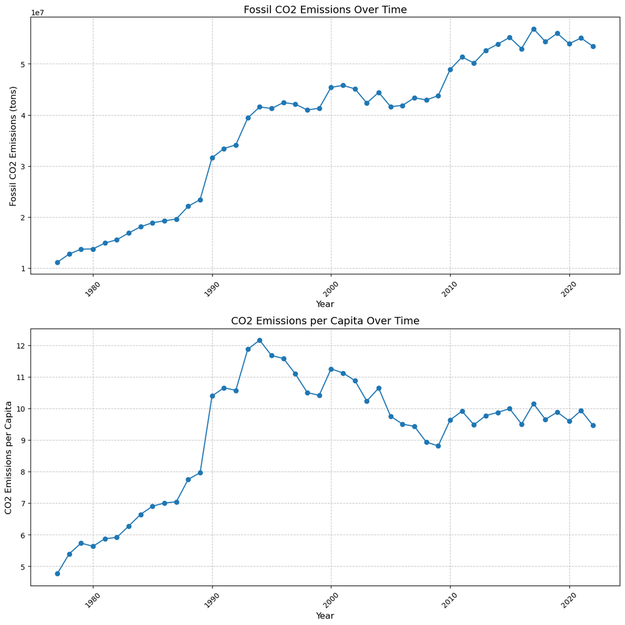

```python
# Create a figure and a set of subplots (2 rows, 1 column)
fig, axes = plt.subplots(2, 1, figsize=(12, 12))  # Adjust figsize for overall size

# Plot 1: Fossil CO2 Emissions (tons)
axes[0].plot(CO2DF['Year'], CO2DF['Fossil CO2 Emissions (tons)'], marker='o', linestyle='-')
axes[0].set_xlabel('Year', fontsize=12)
axes[0].set_ylabel('Fossil CO2 Emissions (tons)', fontsize=12)
axes[0].set_title('Fossil CO2 Emissions Over Time', fontsize=14)
axes[0].tick_params(axis='x', rotation=45, labelsize=10) # Combined tick rotation and fontsize
axes[0].tick_params(axis='y', labelsize=10)
axes[0].grid(True, linestyle='--', alpha=0.7)

# Plot 2: CO2 emissions per capita
axes[1].plot(CO2DF['Year'], CO2DF['CO2 emissions per capita'], marker='o', linestyle='-')
axes[1].set_xlabel('Year', fontsize=12)
axes[1].set_ylabel('CO2 Emissions per Capita', fontsize=12)
axes[1].set_title('CO2 Emissions per Capita Over Time', fontsize=14)
axes[1].tick_params(axis='x', rotation=45, labelsize=10) # Combined tick rotation and fontsize
axes[1].tick_params(axis='y', labelsize=10)
axes[1].grid(True, linestyle='--', alpha=0.7)

# Improve spacing between subplots
plt.tight_layout() # Important: Call tight_layout *after* all subplots are created

plt.show()
```

**Carbon dioxide emissions** have generally increased over the years. However, **CO₂ emissions per capita** saw their **highest peak around 1995** before experiencing a **decline**. After reaching a certain level, the emissions per capita **stabilized** but continued to **fluctuate within a specific range until 2022**.

### Does population have an impact on CO2 emissions?

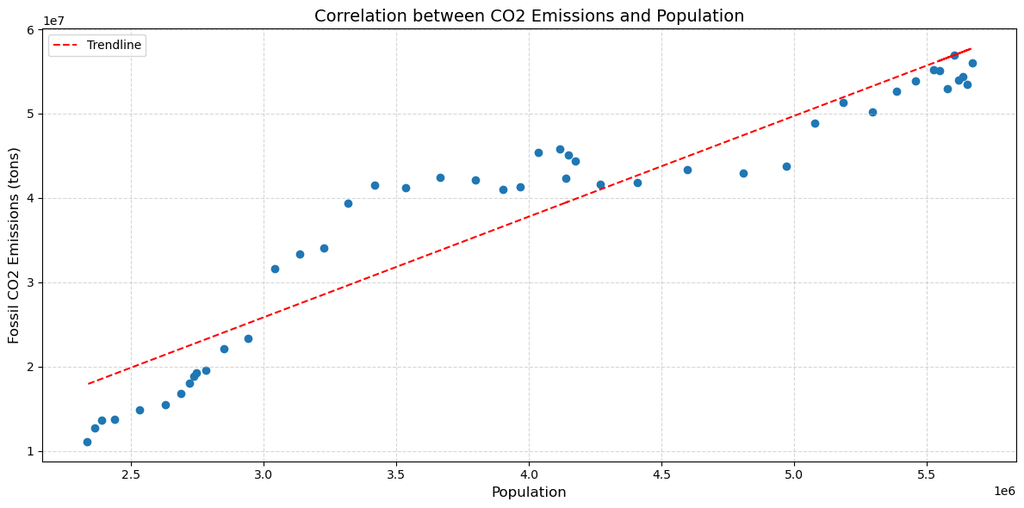

```python
plt.figure(figsize=(12, 6))

plt.scatter(CO2DF['Population'], CO2DF['Fossil CO2 Emissions (tons)'])

plt.xlabel('Population', fontsize=12)
plt.ylabel('Fossil CO2 Emissions (tons)', fontsize=12)
plt.title('Correlation between CO2 Emissions and Population', fontsize=14)  # More descriptive title

plt.xticks(fontsize=10)
plt.yticks(fontsize=10)

plt.grid(True, linestyle='--', alpha=0.5)

# Add a trendline (optional but often helpful):
import numpy as np
z = np.polyfit(CO2DF['Population'], CO2DF['Fossil CO2 Emissions (tons)'], 1)  # Fit a 1st-degree polynomial (line)
p = np.poly1d(z)
plt.plot(CO2DF['Population'], p(CO2DF['Population']), "r--", label="Trendline")  # Plot the trendline

plt.legend(fontsize=10) # Show legend for the trendline

plt.tight_layout()
plt.show()
```

As the **population increases**, **CO₂ emissions** also **rise**. This is likely due to higher energy consumption and industrial activities.

### How does an increase in temperature impact humidity levels?

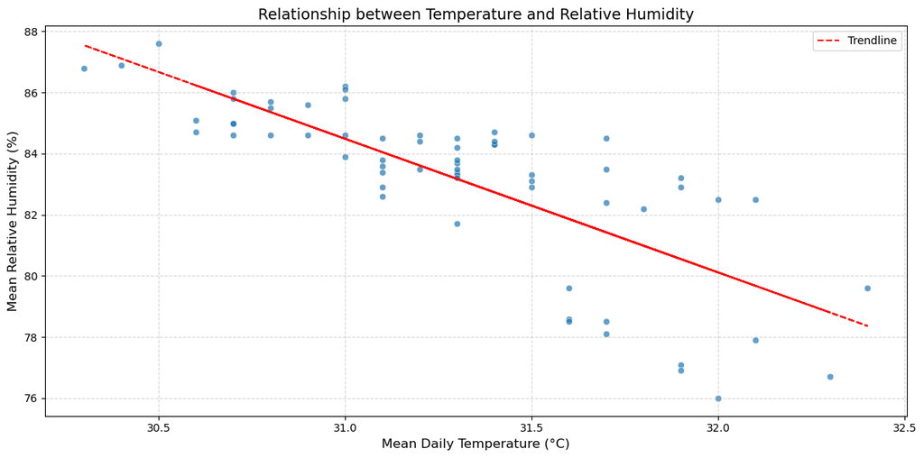

```python
max_temp = WeatherDF['Air Temperature Means Daily Maximum'].to_numpy()
min_temp = WeatherDF['Air Temperature Means Daily Maximum'].to_numpy() # Corrected: min_temp should be different from max_temp if you have different min and max values. If this column is not available, you should use a different way to calculate the mean temperature
mean_temp = (max_temp + min_temp) / 2

humidity = WeatherDF['24 Hours Mean Relative Humidity'].to_numpy()

plt.figure(figsize=(12, 6))

plt.scatter(mean_temp, humidity, alpha=0.7, edgecolors='w', linewidths=0.5)

plt.xlabel('Mean Daily Temperature (°C)', fontsize=12)  # More descriptive label with units
plt.ylabel('Mean Relative Humidity (%)', fontsize=12)  # More descriptive label with units
plt.title('Relationship between Temperature and Relative Humidity', fontsize=14)  # More descriptive title

plt.xticks(fontsize=10)
plt.yticks(fontsize=10)

plt.grid(True, linestyle='--', alpha=0.5)

# Add a trendline (optional but often helpful):
z = np.polyfit(mean_temp, humidity, 1)  # Fit a 1st-degree polynomial (line)
p = np.poly1d(z)
plt.plot(mean_temp, p(mean_temp), "r--", label="Trendline")

plt.legend(fontsize=10)

plt.tight_layout()
plt.show()
```

Warmer temperatures generally correlate with lower relative humidity, as warmer air can hold more moisture, causing the relative humidity to decrease unless additional moisture is added. However, absolute humidity (the total amount of water vapor in the air) may still be high in warm conditions.

### What impact do energy consumption have on CO₂ emissions?

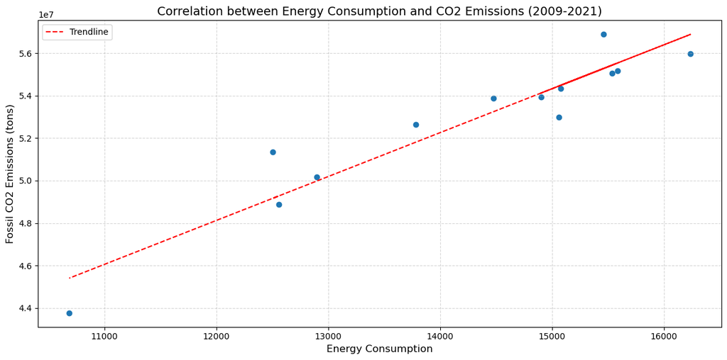

```python
energy_consumption = EnergyDF.loc[EnergyDF['DataSeries'] == 'Total']
CO2DF['Year'] = CO2DF['Year'].astype(int)

energy_values = energy_consumption.iloc[0, 1:].values.astype(float).flatten()
co2_emissions = CO2DF['Fossil CO2 Emissions (tons)']
co2_emissions = co2_emissions[(CO2DF['Year'] <= 2021) & (CO2DF['Year'] >= 2009)].to_numpy()

plt.figure(figsize=(12, 6))

plt.scatter(energy_values, co2_emissions)

plt.xlabel('Energy Consumption', fontsize=12)
plt.ylabel('Fossil CO2 Emissions (tons)', fontsize=12)
plt.title('Correlation between Energy Consumption and CO2 Emissions (2009-2021)', fontsize=14)

plt.xticks(fontsize=10)
plt.yticks(fontsize=10)

plt.grid(True, linestyle='--', alpha=0.5)

# Add a trendline (optional)
z = np.polyfit(energy_values, co2_emissions, 1)
p = np.poly1d(z)
plt.plot(energy_values, p(energy_values), "r--", label="Trendline")

plt.legend(fontsize=10)

plt.tight_layout()
plt.show()
```

Generally, as energy consumption increases, CO₂ emissions also increase.

### Which sectors exhibit the greatest variability in energy consumption over the years?

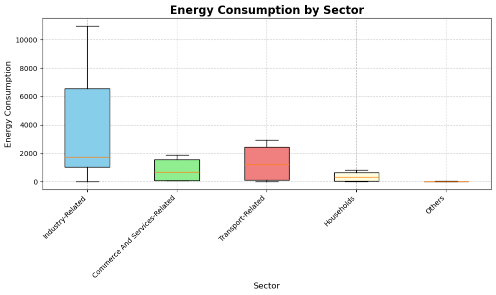

```python
categories = ['Industry-Related', 'Commerce And Services-Related', 'Transport-Related', 'Households', 'Others']
data = []

for category in categories:
    filtered_df = EnergyDF.loc[EnergyDF['DataSeries'] == category, EnergyDF.columns != 'DataSeries']
    filtered_df = filtered_df.loc[(filtered_df > 0).any(axis=1)]  # Keep rows with at least one value > 0
    data.append(filtered_df.values.ravel())  # Append the flattened array to the data list

fig, ax = plt.subplots(figsize=(10, 6))  # Adjust figure size for better visibility

# Plot the box plot (more efficient)
boxplot_parts = ax.boxplot(data, positions=range(1, len(categories) + 1), widths=0.5, patch_artist=True, showfliers=True)  # Added showfliers

# Set colors for the boxes (optional)
colors = ['skyblue', 'lightgreen', 'lightcoral', 'lightyellow', 'lightcyan']  # Customize colors as needed
for i, box in enumerate(boxplot_parts['boxes']):
    box.set(facecolor=colors[i])

# Set the x-axis labels
ax.set_xticklabels(categories, rotation=45, ha='right', fontsize=10)  # Improved rotation and fontsize

# Improved labels and title
ax.set_title('Energy Consumption by Sector', fontsize=16, fontweight='bold')
ax.set_ylabel('Energy Consumption', fontsize=12)
ax.set_xlabel('Sector', fontsize=12)

ax.grid(True, linestyle='--', alpha=0.7)

# Add a legend (optional, but can be helpful)
# You could add a legend if you want to label the boxes, but in this case, the x-axis labels are clear enough.

plt.tight_layout() # Adjust layout to prevent labels from overlapping
plt.show()
```

Analyzing the variability of energy consumption across different sectors over the past 12 years.

- **Industry-related sectors** have the highest variability in energy use, likely due to changes in production levels, efficiency improvements, or shifts in energy sources.
- **Transport-related sectors** follow, which makes sense as fuel consumption can fluctuate with economic activity, policies, and technological advancements.
- **Commerce and service-related sectors and households** show minimal variation, possibly because their energy needs are more stable over time.

### How is energy consumption distributed across different sectors in 2021?

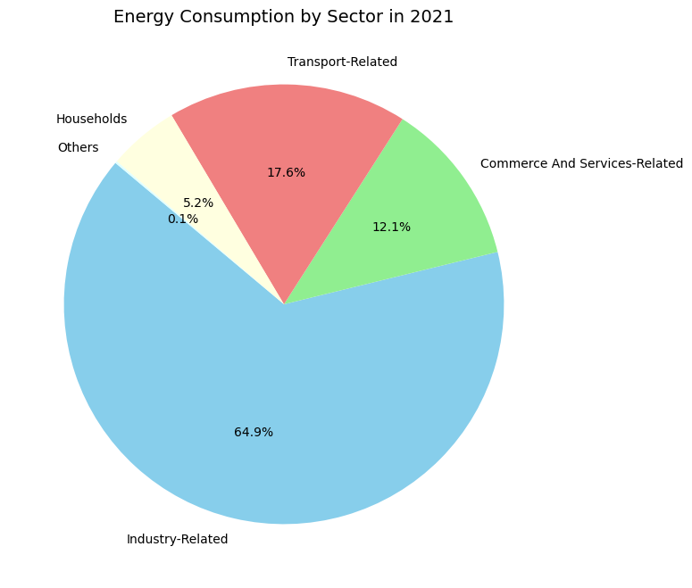

```python
year = 2021  # Choose a year

sectors = [
    'Industry-Related',
    'Commerce And Services-Related',
    'Transport-Related',
    'Households',
    'Others'
]

filtered_data = []
labels = []  # Store labels for which data is found

for sector_name in sectors:
    data = EnergyDF.loc[EnergyDF['DataSeries'] == sector_name, str(year)]
    filtered_data.append(data.iloc[0])
    labels.append(sector_name)  # Add label only if data is found

filtered_data = np.array(filtered_data)
total = filtered_data.sum()
percentage = (filtered_data / total) * 100

plt.figure(figsize=(8, 8))
plt.pie(percentage,labels=labels,autopct="%1.1f%%",startangle=140,
        colors=[  # Add some colors
            "skyblue",
            "lightgreen",
            "lightcoral",
            "lightyellow",
            "lightcyan",
              ],
       )

plt.title(f'Energy Consumption by Sector in {year}', fontsize=14)  # Corrected title
plt.show()
```

The breakdown of Singapore's energy consumption in 2021 highlights the dominance of the **industry-related sector**, which consumed more than half of the total energy. The **transportation sector** followed, likely due to fuel consumption for vehicles, shipping, and aviation. **Commerce and service-related sectors** came next, while **households accounted** for only about 5%. Other sectors, like agriculture or small-scale industries, consumed a negligible amount.

### Are there any specific energy types that stand out in terms of their consumption levels?

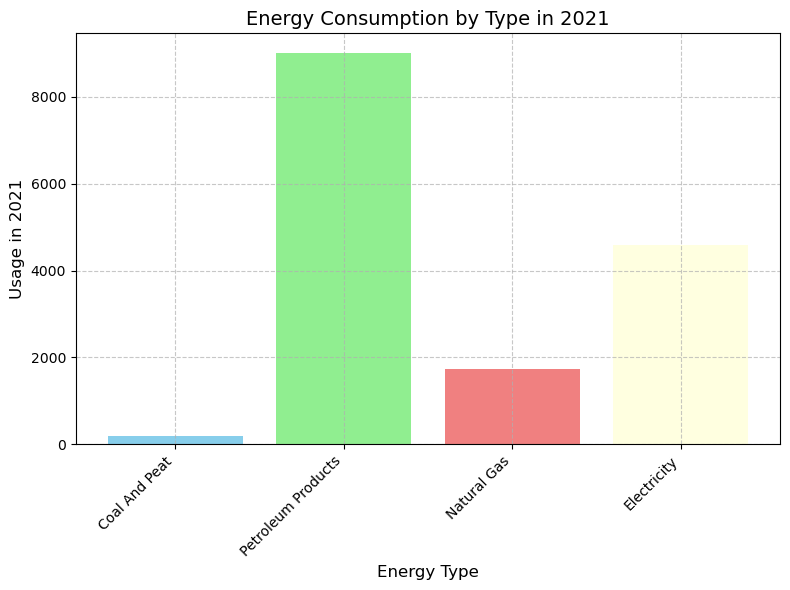

```python
year = 2021  # Choose a year

energy_types = ['Coal And Peat', 'Petroleum Products', 'Natural Gas', 'Electricity']

energy_data = []
labels = []

for energy_type in energy_types:
    data = EnergyDF.loc[EnergyDF['DataSeries'] == energy_type, str(year)]
    energy_data.append(data.iloc[0])
    labels.append(energy_type)

energy_data = np.array(energy_data)

plt.figure(figsize=(8, 6))
plt.bar(labels, energy_data, color=['skyblue', 'lightgreen', 'lightcoral', 'lightyellow'])

plt.xlabel("Energy Type", fontsize=12)
plt.ylabel(f"Usage in {year}", fontsize=12)
plt.title(f"Energy Consumption by Type in {year}", fontsize=14)
plt.xticks(rotation=45, ha='right', fontsize=10)
plt.yticks(fontsize=10)
plt.grid(True, linestyle='--', alpha=0.7)

plt.tight_layout()
plt.show()
```

The analysis of Singapore's 2021 energy consumption by source shows that:

- **Petroleum** had the highest consumption, likely due to its use in transportation and industry.
- **Electricity** came second, powering homes, businesses, and industries.
- **Natural gas** was third, mainly used for power generation.
- **Coal and peat** had minimal usage.